# Nima Saed

Application Security Architect | Software Security Engineer  
Ethical Hacker | DevSecOps Engineer | Cloud Security Engineer

- nmsd.xyz
- [LinkedIn](https://www.linkedin.com/in/nimasaed/)
- nima@nmsd.xyz
- 00 31 6 14 61 20 95

## Biography

I am a seasoned security expert with 19 years of experience in IT, including 13 years specializing in software and cloud security. My expertise lies in securing critical systems, particularly in authentication, authorization, and cryptography. I excel at automating security processes and integrating them into modern software development lifecycles (SSDLC).

Over my career, I’ve collaborated across industries such as healthcare, education, manufacturing, and technology, addressing their unique privacy and security challenges. My approach centers on making security a seamless enabler for innovation by championing automation and simplicity.

As a trainer and mentor, I am passionate about empowering teams to adopt secure development practices and strengthen their security postures. Whether through penetration testing, threat modeling, or building secure cloud infrastructures, my goal is to ensure businesses thrive in the digital age while staying secure.

## About Me

My journey into cybersecurity started during my teenage years, sparked by a fascination with hacking and defense mechanisms. Friendly “Capture the Flag” competitions with friends fueled my curiosity about how systems operate—and how to secure them. This passion eventually became my career.

To deepen my expertise, I pursued formal education in security technology and cryptography, learning to secure software and build robust systems. Along the way, I’ve developed a knack for tackling complex challenges and finding innovative solutions, both professionally and personally.

In my free time, I’m an enthusiastic maker and tech tinkerer. I enjoy experimenting with electronics and microcontrollers, automating my home, and now, creating with 3D modeling and 3D printing. These hobbies give me a hands-on outlet for creativity and problem-solving, skills I bring to all aspects of my work.

# Professional Experience

## ANVA (May 2024 – Present)

**Security Architect**

- Designed and implemented secure architecture for a new SaaS product.
- Specialized in authentication and authorization, secure software development, and secure CI/CD environments.
- Key Achievement:
  - Developed a modern authorization engine to enhance data security for a SaaS product.

## Xebia (Nov 2021 – April 2024)

**Security Consultant**

Nima provided consultancy services in digital transformation and security processes across diverse industries.

- Automated security checks in CI/CD pipelines.
- Conducted AWS cloud security assessments and enhanced infrastructure security.
- Performed penetration tests, secure code reviews, and threat modeling for application designs.
- Delivered training on AWS security, application security, and DevSecOps practices.

Key Focus: Making security an enabler through automation and simplicity, empowering clients to strengthen their security posture effectively.

## 247TailorSteel (Dec 2019 – Oct 2021)

**Information Security Engineer**

- Integrated API security scans into development pipelines.
- Designed a secure authentication and authorization platform for a customer portal.
- Implemented automated network vulnerability scans for OT security, identifying factory floor vulnerabilities.

## Dassault Systèmes (Sep 2016 – Dec 2019)

**Software Security Engineer**

- Conducted penetration tests on in-house software and services.
- Advocated for a shift-left approach in the SDLC, embedding security into design and testing phases.
- Key Achievement: Successfully identified critical vulnerabilities in SAML authentication before release.

[figure not shown]

## Multimedia University (Sep 2014 – Aug 2016)

**Research Assistant & Tutor**

- Research Focus: Conducted research in cryptography and searchable encryption, exploring innovative methods for enhancing security and privacy.
- Tutoring: Assisted undergraduate students in topics such as C++ programming, data structures in C++, and web technologies.

Key Contributions:

- Desgined Public Key Encryption with keyword Search Scheme. [link to PEKS Scheme](https://docs.google.com/document/d/1Lhy_PnInp-IzHgyPo7FE3gm5dPC_6KA15z4qpzf0Pao/edit?usp=sharing)
- Discovered a method to reuse singcryption schemes in PEKS.

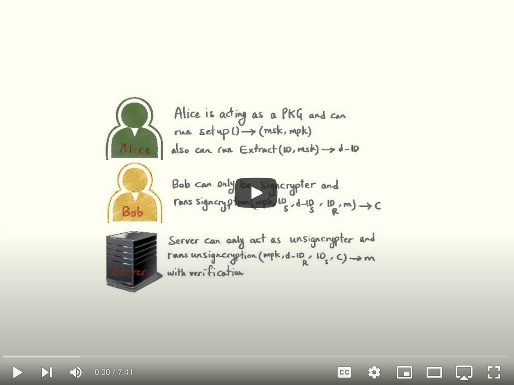

## Previous Experience

**Network Administrator (Jan 2003 – Jun 2009)**

- Managed and optimized network performance, security, and overall infrastructure.
- Firewall & Security Administration: Administered firewalls, conducted security monitoring, and implemented network systems security audits.
- LAN Expansion & Design: Planned and executed the organization’s LAN network expansion, including server upgrades and configuration of Microsoft Windows Server and network-based routers.
- Collaboration with Management: Worked with the management team to develop security policies and provide technical support for application systems.
- Systems Maintenance: Responsible for backup of file servers, ISA server administration, and general network management.

# Education

- 2014: Bachelor of I.T. (Hons) in Security Technology, Multimedia University, Malaysia
- 2016: Cryptography, Multimedia University, Malaysia

## Awards

- ECA MMU Chapter Award for Security Technology, EC-Council, Convocation 2014
  - Issued by Faculty of Information Science and Technology and EC-Council, Multimedia University
- Five Dean Awards
  - Issued by Faculty of Information Science and Technology, Multimedia University

## Publications

Peer-Reviewed Articles

- [Video and Voice Transmission over LTE Networks](https://ieeexplore.ieee.org/abstract/document/6719970)
  - Authors: N. Saed, T.H. Liew, K. Wee, S.Y. Ooi
  - Published in: 2013 IEEE International Conference on Control System, Computing and Engineering
  - Year: 2013
- [Low Complexity in Exaggerated Earliest Deadline First Approach for Channel and QoS-aware Scheduler](https://www.jocm.us/show-138-743-1.html)
  - Authors: N. Saed, K. Wee, C. Siew-Chin, T.H. Liew, Y.Y. Wee
  - Published in: J. Commun. 9(11), 884-890
  - Year: 2014
- [A Performance Study of Downlink Scheduling Algorithms in Wireless Broadband Networks](https://www.jocm.us/index.php?m=content&c=index&a=show&catid=128&id=625)
  - Authors: K. Wee, Muhd. Hilmi B.A. H, Y.Y. Wee, N. Saed
  - Published in: J. Commun. 9(1), 39-47
  - Year: 2014

## Competences

- Secure Architecture & Design
- Training and Mentoring
- Penetration Testing & Social Engineering
- Threat Modeling
- Security Test Automation
- Secure Software Development
- Secure CI/CD Environments & SSDLC
- Cloud Security

## Languages

- English: Fluent
- Persian: Native
- Kurdish: Intermediate
- Chinese: Beginner
- Dutch: Beginner

## Hobbies

- Linux Ricing
- Electronics and Microcontrollers
- Smart Home Automation
- 3D Design and Printing